# Optimal Treatment Analysis

## Outcome Variable

**Outcome Variable:** haz

## Predictor Variables

**Intervention Variable:** predfeed36

**Adjustment Set:**

- arm
- sex
- month
- brthmon
- W_mage
- meducyrs
- feducyrs
- hhwealth_quart
- hfoodsec
- W_mhtcm
- vagbrth
- W_gagebrth
- W_birthwt
- W_birthlen
- W_nrooms
- W_nchldlt5
- W_parity
- impfloor
- impsan
- safeh20
- delta_W_mage
- delta_meducyrs
- delta_feducyrs
- delta_hhwealth_quart
- delta_hfoodsec
- delta_W_mhtcm
- delta_vagbrth
- delta_W_gagebrth
- delta_W_birthwt
- delta_W_birthlen
- delta_W_nrooms
- delta_W_nchldlt5
- delta_W_parity
- delta_impfloor
- delta_impsan
- delta_safeh20

## Stratifying Variables

The analysis was stratified on these variable(s):

- agecat
- studyid
- country

## Data Summary

| agecat | studyid | country | predfeed36 | n_cell | n |
| --- | --- | --- | --- | --- | --- |
| Birth | ki0047075b-MAL-ED | BANGLADESH | 1 | 125 | 243 |
| Birth | ki0047075b-MAL-ED | BANGLADESH | 0 | 118 | 243 |
| Birth | ki0047075b-MAL-ED | BRAZIL | 1 | 29 | 185 |
| Birth | ki0047075b-MAL-ED | BRAZIL | 0 | 156 | 185 |
| Birth | ki0047075b-MAL-ED | INDIA | 1 | 16 | 198 |
| Birth | ki0047075b-MAL-ED | INDIA | 0 | 182 | 198 |
| Birth | ki0047075b-MAL-ED | NEPAL | 1 | 26 | 172 |
| Birth | ki0047075b-MAL-ED | NEPAL | 0 | 146 | 172 |
| Birth | ki0047075b-MAL-ED | PERU | 1 | 118 | 273 |
| Birth | ki0047075b-MAL-ED | PERU | 0 | 155 | 273 |
| Birth | ki0047075b-MAL-ED | SOUTH AFRICA | 1 | 3 | 236 |
| Birth | ki0047075b-MAL-ED | SOUTH AFRICA | 0 | 233 | 236 |
| Birth | ki0047075b-MAL-ED | TANZANIA, UNITED REPUBLIC OF | 1 | 1 | 121 |
| Birth | ki0047075b-MAL-ED | TANZANIA, UNITED REPUBLIC OF | 0 | 120 | 121 |
| Birth | ki1000109-EE | PAKISTAN | 1 | 1 | 2 |
| Birth | ki1000109-EE | PAKISTAN | 0 | 1 | 2 |
| Birth | kiGH5241-JiVitA-3 | BANGLADESH | 1 | 11176 | 13946 |
| Birth | kiGH5241-JiVitA-3 | BANGLADESH | 0 | 2770 | 13946 |
| Birth | kiGH5241-JiVitA-4 | BANGLADESH | 1 | 582 | 727 |
| Birth | kiGH5241-JiVitA-4 | BANGLADESH | 0 | 145 | 727 |
| 6 months | ki0047075b-MAL-ED | BANGLADESH | 1 | 129 | 240 |
| 6 months | ki0047075b-MAL-ED | BANGLADESH | 0 | 111 | 240 |
| 6 months | ki0047075b-MAL-ED | BRAZIL | 1 | 37 | 209 |
| 6 months | ki0047075b-MAL-ED | BRAZIL | 0 | 172 | 209 |
| 6 months | ki0047075b-MAL-ED | INDIA | 1 | 19 | 236 |
| 6 months | ki0047075b-MAL-ED | INDIA | 0 | 217 | 236 |
| 6 months | ki0047075b-MAL-ED | NEPAL | 1 | 32 | 236 |
| 6 months | ki0047075b-MAL-ED | NEPAL | 0 | 204 | 236 |
| 6 months | ki0047075b-MAL-ED | PERU | 1 | 126 | 271 |
| 6 months | ki0047075b-MAL-ED | PERU | 0 | 145 | 271 |
| 6 months | ki0047075b-MAL-ED | SOUTH AFRICA | 1 | 3 | 254 |
| 6 months | ki0047075b-MAL-ED | SOUTH AFRICA | 0 | 251 | 254 |
| 6 months | ki0047075b-MAL-ED | TANZANIA, UNITED REPUBLIC OF | 1 | 2 | 247 |
| 6 months | ki0047075b-MAL-ED | TANZANIA, UNITED REPUBLIC OF | 0 | 245 | 247 |
| 6 months | ki1000109-EE | PAKISTAN | 1 | 222 | 367 |
| 6 months | ki1000109-EE | PAKISTAN | 0 | 145 | 367 |
| 6 months | ki1000304b-SAS-FoodSuppl | INDIA | 1 | 0 | 168 |
| 6 months | ki1000304b-SAS-FoodSuppl | INDIA | 0 | 168 | 168 |
| 6 months | ki1113344-GMS-Nepal | NEPAL | 1 | 423 | 526 |
| 6 months | ki1113344-GMS-Nepal | NEPAL | 0 | 103 | 526 |
| 6 months | ki1148112-LCNI-5 | MALAWI | 1 | 47 | 272 |
| 6 months | ki1148112-LCNI-5 | MALAWI | 0 | 225 | 272 |
| 6 months | kiGH5241-JiVitA-3 | BANGLADESH | 1 | 10705 | 13375 |
| 6 months | kiGH5241-JiVitA-3 | BANGLADESH | 0 | 2670 | 13375 |
| 6 months | kiGH5241-JiVitA-4 | BANGLADESH | 1 | 3256 | 4171 |
| 6 months | kiGH5241-JiVitA-4 | BANGLADESH | 0 | 915 | 4171 |
| 24 months | ki0047075b-MAL-ED | BANGLADESH | 1 | 117 | 211 |
| 24 months | ki0047075b-MAL-ED | BANGLADESH | 0 | 94 | 211 |
| 24 months | ki0047075b-MAL-ED | BRAZIL | 1 | 30 | 169 |
| 24 months | ki0047075b-MAL-ED | BRAZIL | 0 | 139 | 169 |
| 24 months | ki0047075b-MAL-ED | INDIA | 1 | 18 | 227 |
| 24 months | ki0047075b-MAL-ED | INDIA | 0 | 209 | 227 |
| 24 months | ki0047075b-MAL-ED | NEPAL | 1 | 30 | 228 |
| 24 months | ki0047075b-MAL-ED | NEPAL | 0 | 198 | 228 |
| 24 months | ki0047075b-MAL-ED | PERU | 1 | 94 | 200 |
| 24 months | ki0047075b-MAL-ED | PERU | 0 | 106 | 200 |
| 24 months | ki0047075b-MAL-ED | SOUTH AFRICA | 1 | 3 | 238 |
| 24 months | ki0047075b-MAL-ED | SOUTH AFRICA | 0 | 235 | 238 |
| 24 months | ki0047075b-MAL-ED | TANZANIA, UNITED REPUBLIC OF | 1 | 2 | 214 |
| 24 months | ki0047075b-MAL-ED | TANZANIA, UNITED REPUBLIC OF | 0 | 212 | 214 |
| 24 months | ki1113344-GMS-Nepal | NEPAL | 1 | 369 | 456 |
| 24 months | ki1113344-GMS-Nepal | NEPAL | 0 | 87 | 456 |
| 24 months | ki1148112-LCNI-5 | MALAWI | 1 | 34 | 189 |
| 24 months | ki1148112-LCNI-5 | MALAWI | 0 | 155 | 189 |
| 24 months | kiGH5241-JiVitA-3 | BANGLADESH | 1 | 5293 | 6693 |
| 24 months | kiGH5241-JiVitA-3 | BANGLADESH | 0 | 1400 | 6693 |
| 24 months | kiGH5241-JiVitA-4 | BANGLADESH | 1 | 3153 | 4023 |
| 24 months | kiGH5241-JiVitA-4 | BANGLADESH | 0 | 870 | 4023 |

The following strata were considered:

- agecat: 24 months, studyid: ki0047075b-MAL-ED, country: BANGLADESH
- agecat: 24 months, studyid: ki0047075b-MAL-ED, country: BRAZIL
- agecat: 24 months, studyid: ki0047075b-MAL-ED, country: INDIA
- agecat: 24 months, studyid: ki0047075b-MAL-ED, country: NEPAL
- agecat: 24 months, studyid: ki0047075b-MAL-ED, country: PERU
- agecat: 24 months, studyid: ki0047075b-MAL-ED, country: SOUTH AFRICA
- agecat: 24 months, studyid: ki0047075b-MAL-ED, country: TANZANIA, UNITED REPUBLIC OF
- agecat: 24 months, studyid: ki1113344-GMS-Nepal, country: NEPAL
- agecat: 24 months, studyid: ki1148112-LCNI-5, country: MALAWI
- agecat: 24 months, studyid: kiGH5241-JiVitA-3, country: BANGLADESH
- agecat: 24 months, studyid: kiGH5241-JiVitA-4, country: BANGLADESH
- agecat: 6 months, studyid: ki0047075b-MAL-ED, country: BANGLADESH
- agecat: 6 months, studyid: ki0047075b-MAL-ED, country: BRAZIL
- agecat: 6 months, studyid: ki0047075b-MAL-ED, country: INDIA
- agecat: 6 months, studyid: ki0047075b-MAL-ED, country: NEPAL
- agecat: 6 months, studyid: ki0047075b-MAL-ED, country: PERU
- agecat: 6 months, studyid: ki0047075b-MAL-ED, country: SOUTH AFRICA
- agecat: 6 months, studyid: ki0047075b-MAL-ED, country: TANZANIA, UNITED REPUBLIC OF
- agecat: 6 months, studyid: ki1000109-EE, country: PAKISTAN
- agecat: 6 months, studyid: ki1000304b-SAS-FoodSuppl, country: INDIA
- agecat: 6 months, studyid: ki1113344-GMS-Nepal, country: NEPAL
- agecat: 6 months, studyid: ki1148112-LCNI-5, country: MALAWI
- agecat: 6 months, studyid: kiGH5241-JiVitA-3, country: BANGLADESH
- agecat: 6 months, studyid: kiGH5241-JiVitA-4, country: BANGLADESH
- agecat: Birth, studyid: ki0047075b-MAL-ED, country: BANGLADESH
- agecat: Birth, studyid: ki0047075b-MAL-ED, country: BRAZIL
- agecat: Birth, studyid: ki0047075b-MAL-ED, country: INDIA
- agecat: Birth, studyid: ki0047075b-MAL-ED, country: NEPAL
- agecat: Birth, studyid: ki0047075b-MAL-ED, country: PERU
- agecat: Birth, studyid: ki0047075b-MAL-ED, country: SOUTH AFRICA
- agecat: Birth, studyid: ki0047075b-MAL-ED, country: TANZANIA, UNITED REPUBLIC OF
- agecat: Birth, studyid: ki1000109-EE, country: PAKISTAN
- agecat: Birth, studyid: kiGH5241-JiVitA-3, country: BANGLADESH
- agecat: Birth, studyid: kiGH5241-JiVitA-4, country: BANGLADESH

### Dropped Strata

Some strata were dropped due to rare outcomes:

- agecat: Birth, studyid: ki0047075b-MAL-ED, country: SOUTH AFRICA
- agecat: Birth, studyid: ki0047075b-MAL-ED, country: TANZANIA, UNITED REPUBLIC OF
- agecat: Birth, studyid: ki1000109-EE, country: PAKISTAN
- agecat: 6 months, studyid: ki0047075b-MAL-ED, country: SOUTH AFRICA
- agecat: 6 months, studyid: ki0047075b-MAL-ED, country: TANZANIA, UNITED REPUBLIC OF
- agecat: 6 months, studyid: ki1000304b-SAS-FoodSuppl, country: INDIA
- agecat: 24 months, studyid: ki0047075b-MAL-ED, country: SOUTH AFRICA
- agecat: 24 months, studyid: ki0047075b-MAL-ED, country: TANZANIA, UNITED REPUBLIC OF

## Methods Detail

We’re interested in the causal parameters $E[Y_a]$ for all values of $a \in \mathcal{A}$. These parameters represent the mean outcome if, possibly contrary to fact, we intervened to set all units to have $A=a$. Under the randomization and positivity assumptions, these are identified by the statistical parameters $\psi_a=E_W[E_{Y|A,W}(Y|A=a,W)]$. In addition, we’re interested in the mean of $Y$, $E[Y]$ under no intervention (the observed mean). We will estimate these parameters by using SuperLearner to fit the relevant likelihood factors – $E_{Y|A,W}(Y|A=a,W)$ and $p(A=a|W)$, and then updating our likelihood fit using a joint TMLE.

For unadjusted analyses ($W=\{\}$), initial likelihoods were estimated using Lrnr_glm to estimate the simple $E(Y|A)$ and Lrnr_mean to estimate $p(A)$. For adjusted analyses, a small library containing Lrnr_glmnet, Lrnr_xgboost, and Lrnr_mean was used.

# Results Detail

## Results Plots

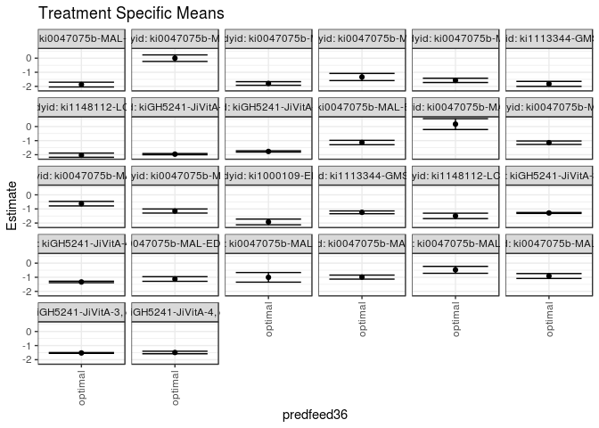

## Results Table

### Parameter: TSM

| agecat | studyid | country | intervention_level | baseline_level | estimate | ci_lower | ci_upper |
| --- | --- | --- | --- | --- | --- | --- | --- |
| Birth | ki0047075b-MAL-ED | BANGLADESH | optimal | observed | -1.1235897 | -1.2874290 | -0.9597505 |
| Birth | ki0047075b-MAL-ED | BRAZIL | optimal | observed | -1.0045958 | -1.3461394 | -0.6630523 |
| Birth | ki0047075b-MAL-ED | INDIA | optimal | observed | -0.9886474 | -1.1329659 | -0.8443290 |
| Birth | ki0047075b-MAL-ED | NEPAL | optimal | observed | -0.4736067 | -0.7194194 | -0.2277939 |
| Birth | ki0047075b-MAL-ED | PERU | optimal | observed | -0.9119503 | -1.0863438 | -0.7375568 |
| Birth | kiGH5241-JiVitA-3 | BANGLADESH | optimal | observed | -1.5226795 | -1.5508419 | -1.4945170 |
| Birth | kiGH5241-JiVitA-4 | BANGLADESH | optimal | observed | -1.4888956 | -1.5790827 | -1.3987085 |
| 6 months | ki0047075b-MAL-ED | BANGLADESH | optimal | observed | -1.1354636 | -1.2917117 | -0.9792154 |
| 6 months | ki0047075b-MAL-ED | BRAZIL | optimal | observed | 0.1704410 | -0.2145077 | 0.5553897 |
| 6 months | ki0047075b-MAL-ED | INDIA | optimal | observed | -1.1473294 | -1.2696939 | -1.0249648 |
| 6 months | ki0047075b-MAL-ED | NEPAL | optimal | observed | -0.6254785 | -0.7852698 | -0.4656873 |
| 6 months | ki0047075b-MAL-ED | PERU | optimal | observed | -1.1487983 | -1.2942268 | -1.0033697 |
| 6 months | ki1000109-EE | PAKISTAN | optimal | observed | -1.9229040 | -2.1260787 | -1.7197293 |
| 6 months | ki1113344-GMS-Nepal | NEPAL | optimal | observed | -1.2413633 | -1.3409298 | -1.1417968 |
| 6 months | ki1148112-LCNI-5 | MALAWI | optimal | observed | -1.4931017 | -1.6835928 | -1.3026107 |
| 6 months | kiGH5241-JiVitA-3 | BANGLADESH | optimal | observed | -1.2862809 | -1.3178982 | -1.2546637 |
| 6 months | kiGH5241-JiVitA-4 | BANGLADESH | optimal | observed | -1.3339365 | -1.3860202 | -1.2818528 |
| 24 months | ki0047075b-MAL-ED | BANGLADESH | optimal | observed | -1.8736668 | -2.0446584 | -1.7026751 |
| 24 months | ki0047075b-MAL-ED | BRAZIL | optimal | observed | 0.0014503 | -0.2308616 | 0.2337623 |
| 24 months | ki0047075b-MAL-ED | INDIA | optimal | observed | -1.7944256 | -1.9225682 | -1.6662830 |
| 24 months | ki0047075b-MAL-ED | NEPAL | optimal | observed | -1.3349194 | -1.5888598 | -1.0809791 |
| 24 months | ki0047075b-MAL-ED | PERU | optimal | observed | -1.5743809 | -1.7262831 | -1.4224786 |
| 24 months | ki1113344-GMS-Nepal | NEPAL | optimal | observed | -1.8235107 | -2.0004426 | -1.6465788 |
| 24 months | ki1148112-LCNI-5 | MALAWI | optimal | observed | -2.0348128 | -2.1839969 | -1.8856287 |
| 24 months | kiGH5241-JiVitA-3 | BANGLADESH | optimal | observed | -1.9610418 | -2.0040811 | -1.9180025 |
| 24 months | kiGH5241-JiVitA-4 | BANGLADESH | optimal | observed | -1.7691256 | -1.8149266 | -1.7233245 |

### Parameter: E(Y)

| agecat | studyid | country | intervention_level | baseline_level | estimate | ci_lower | ci_upper |
| --- | --- | --- | --- | --- | --- | --- | --- |
| Birth | ki0047075b-MAL-ED | BANGLADESH | observed | observed | -1.0414815 | -1.1687478 | -0.9142151 |
| Birth | ki0047075b-MAL-ED | BRAZIL | observed | observed | -0.7350811 | -0.8943683 | -0.5757938 |
| Birth | ki0047075b-MAL-ED | INDIA | observed | observed | -1.0235354 | -1.1657122 | -0.8813585 |
| Birth | ki0047075b-MAL-ED | NEPAL | observed | observed | -0.7052907 | -0.8627483 | -0.5478331 |
| Birth | ki0047075b-MAL-ED | PERU | observed | observed | -0.9231136 | -1.0355489 | -0.8106782 |
| Birth | kiGH5241-JiVitA-3 | BANGLADESH | observed | observed | -1.5333680 | -1.5553430 | -1.5113930 |
| Birth | kiGH5241-JiVitA-4 | BANGLADESH | observed | observed | -1.5200688 | -1.6064560 | -1.4336815 |
| 6 months | ki0047075b-MAL-ED | BANGLADESH | observed | observed | -1.2006806 | -1.3182323 | -1.0831288 |
| 6 months | ki0047075b-MAL-ED | BRAZIL | observed | observed | 0.0510207 | -0.0930194 | 0.1950608 |
| 6 months | ki0047075b-MAL-ED | INDIA | observed | observed | -1.2203672 | -1.3387619 | -1.1019726 |
| 6 months | ki0047075b-MAL-ED | NEPAL | observed | observed | -0.5610593 | -0.6737915 | -0.4483272 |
| 6 months | ki0047075b-MAL-ED | PERU | observed | observed | -1.3173678 | -1.4250795 | -1.2096560 |
| 6 months | ki1000109-EE | PAKISTAN | observed | observed | -2.2009401 | -2.3240630 | -2.0778171 |
| 6 months | ki1113344-GMS-Nepal | NEPAL | observed | observed | -1.3150063 | -1.3948049 | -1.2352077 |
| 6 months | ki1148112-LCNI-5 | MALAWI | observed | observed | -1.6395956 | -1.7592633 | -1.5199278 |
| 6 months | kiGH5241-JiVitA-3 | BANGLADESH | observed | observed | -1.3121772 | -1.3366725 | -1.2876819 |
| 6 months | kiGH5241-JiVitA-4 | BANGLADESH | observed | observed | -1.3602409 | -1.3996637 | -1.3208182 |
| 24 months | ki0047075b-MAL-ED | BANGLADESH | observed | observed | -1.9363270 | -2.0622735 | -1.8103806 |
| 24 months | ki0047075b-MAL-ED | BRAZIL | observed | observed | 0.0418343 | -0.1253834 | 0.2090521 |
| 24 months | ki0047075b-MAL-ED | INDIA | observed | observed | -1.8458150 | -1.9718703 | -1.7197596 |
| 24 months | ki0047075b-MAL-ED | NEPAL | observed | observed | -1.2752193 | -1.3954783 | -1.1549603 |
| 24 months | ki0047075b-MAL-ED | PERU | observed | observed | -1.7430000 | -1.8632412 | -1.6227588 |
| 24 months | ki1113344-GMS-Nepal | NEPAL | observed | observed | -1.8785563 | -1.9657607 | -1.7913519 |
| 24 months | ki1148112-LCNI-5 | MALAWI | observed | observed | -1.9605820 | -2.1001715 | -1.8209925 |
| 24 months | kiGH5241-JiVitA-3 | BANGLADESH | observed | observed | -1.9946153 | -2.0246928 | -1.9645378 |
| 24 months | kiGH5241-JiVitA-4 | BANGLADESH | observed | observed | -1.7766542 | -1.8163158 | -1.7369927 |

### Parameter: PAR

| agecat | studyid | country | intervention_level | baseline_level | estimate | ci_lower | ci_upper |
| --- | --- | --- | --- | --- | --- | --- | --- |
| Birth | ki0047075b-MAL-ED | BANGLADESH | optimal | observed | 0.0821083 | -0.0456362 | 0.2098527 |
| Birth | ki0047075b-MAL-ED | BRAZIL | optimal | observed | 0.2695147 | -0.0326814 | 0.5717108 |
| Birth | ki0047075b-MAL-ED | INDIA | optimal | observed | -0.0348879 | -0.0879440 | 0.0181681 |
| Birth | ki0047075b-MAL-ED | NEPAL | optimal | observed | -0.2316840 | -0.4671320 | 0.0037639 |
| Birth | ki0047075b-MAL-ED | PERU | optimal | observed | -0.0111633 | -0.1241594 | 0.1018329 |
| Birth | kiGH5241-JiVitA-3 | BANGLADESH | optimal | observed | -0.0106885 | -0.0276574 | 0.0062804 |
| Birth | kiGH5241-JiVitA-4 | BANGLADESH | optimal | observed | -0.0311732 | -0.0687750 | 0.0064287 |
| 6 months | ki0047075b-MAL-ED | BANGLADESH | optimal | observed | -0.0652170 | -0.1759476 | 0.0455136 |
| 6 months | ki0047075b-MAL-ED | BRAZIL | optimal | observed | -0.1194203 | -0.4599903 | 0.2211498 |
| 6 months | ki0047075b-MAL-ED | INDIA | optimal | observed | -0.0730379 | -0.1319025 | -0.0141732 |
| 6 months | ki0047075b-MAL-ED | NEPAL | optimal | observed | 0.0644192 | -0.0489251 | 0.1777635 |
| 6 months | ki0047075b-MAL-ED | PERU | optimal | observed | -0.1685695 | -0.2819964 | -0.0551427 |
| 6 months | ki1000109-EE | PAKISTAN | optimal | observed | -0.2780360 | -0.4394260 | -0.1166461 |
| 6 months | ki1113344-GMS-Nepal | NEPAL | optimal | observed | -0.0736431 | -0.1481279 | 0.0008418 |
| 6 months | ki1148112-LCNI-5 | MALAWI | optimal | observed | -0.1464939 | -0.2998559 | 0.0068682 |
| 6 months | kiGH5241-JiVitA-3 | BANGLADESH | optimal | observed | -0.0258963 | -0.0455069 | -0.0062856 |
| 6 months | kiGH5241-JiVitA-4 | BANGLADESH | optimal | observed | -0.0263044 | -0.0660332 | 0.0134243 |
| 24 months | ki0047075b-MAL-ED | BANGLADESH | optimal | observed | -0.0626603 | -0.2025044 | 0.0771839 |
| 24 months | ki0047075b-MAL-ED | BRAZIL | optimal | observed | 0.0403840 | -0.1065198 | 0.1872877 |
| 24 months | ki0047075b-MAL-ED | INDIA | optimal | observed | -0.0513894 | -0.0961965 | -0.0065822 |
| 24 months | ki0047075b-MAL-ED | NEPAL | optimal | observed | 0.0597001 | -0.1544651 | 0.2738654 |
| 24 months | ki0047075b-MAL-ED | PERU | optimal | observed | -0.1686191 | -0.2934153 | -0.0438230 |
| 24 months | ki1113344-GMS-Nepal | NEPAL | optimal | observed | -0.0550456 | -0.2004576 | 0.0903665 |
| 24 months | ki1148112-LCNI-5 | MALAWI | optimal | observed | 0.0742308 | -0.0515104 | 0.1999720 |
| 24 months | kiGH5241-JiVitA-3 | BANGLADESH | optimal | observed | -0.0335735 | -0.0629163 | -0.0042307 |
| 24 months | kiGH5241-JiVitA-4 | BANGLADESH | optimal | observed | -0.0075287 | -0.0338994 | 0.0188421 |